# Logistic Regression

## Logistic Regression

Used when your DV is binary (0,1)  
- Clinical diagnosis  
- Disease prevalence  
- Experiences (Yes/No)

## Assumption violations

Violates:  
- Correctly specified form  
- Homoscedasticity  
- Normality of the errors

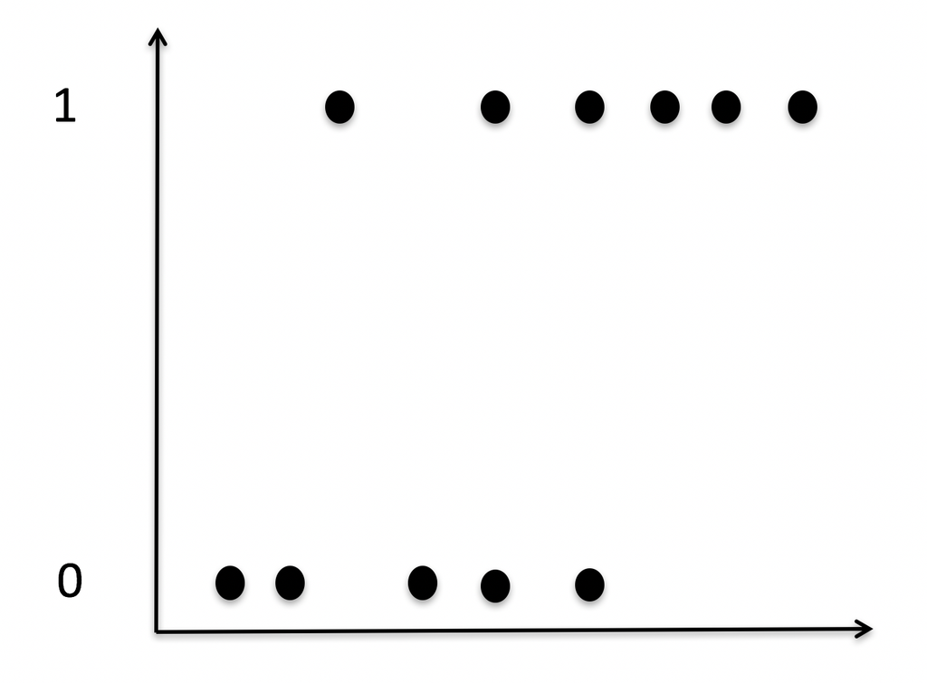

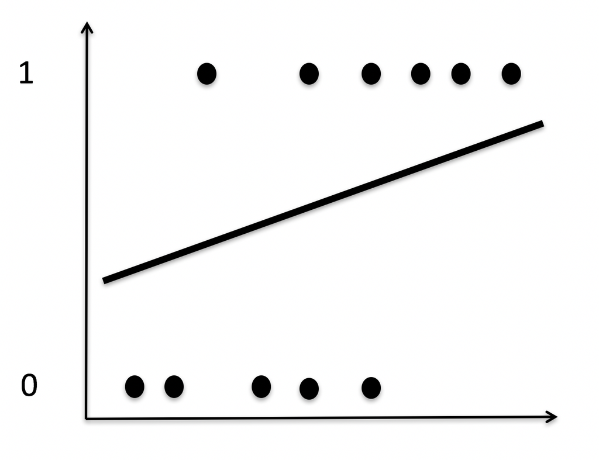

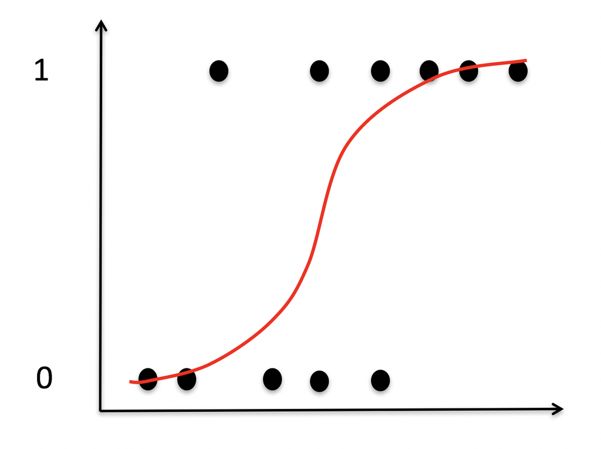

## Need to think in terms of probabilities

- If we use OLS, we violate assumptions and have predicted values that go outside 0 & 1
- How does the predicted probability of getting a 0 or a 1 relate to our predictors?

\[ \hat{p}_{i} \leftrightsquigarrow b_{0} + b_{1}X_{1} + b_{2}X_{2}... b_{3}X_{p} \]

## Generalized linear models

- extend the general linear model framework
- need to use if the range of Y is restricted (e.g. binary, count) and/or the variance of Y depends on the mean
- made up of two functions
1. Link Function - describes how the mean depends on the predictors \(g(\mu) = \eta_{i}\)
2. Variance Function - describes how the variance depends on the mean \(var(Y)=\phi V(\mu)\)

## Error structure

In LMs, we assume that the errors \(ε_{i}\) are independent and identically distributed such that  
\(E[ε_{i}] = 0\) and \(var[ε_{i}] = s^2\)  
Typically we assume \(ε_{i}\sim N(0,σ^2)\) as a basis for inference, e.g. t-tests

## Generalized linear model

- need to accomplish two goals:
  1. specify a link function
  2. need to specify the error structure
- luckily this handled together

## General Linear Model

- GLM (aka regression as you know it) is a special case of Generalized Linear Models
- Link function (describes how the mean depends on the predictors) is \(g(\mu) = \mu\).
- Variance Function (describes how the variance depends on the mean, related to a particular distribution) \(\phi V(\mu) = 1*\sigma^2\)
- in other words, it assumes the gaussian normal distribution
- In some situations (not when working with a dichotomous outcome) an IV variable can be transformed to improve linearity and homogeneity of variance
- problems:  
  + response variable has changed!  
  + transformation must simulateneously improve linearity and homogeneity of variance  
  + transformation may not be defined by the boundaries of the sample space

## Link function for logistc

- we need to map (0,1) to \((-\infty, \infty)\)
- Logistic regression uses the logistic function to link the predicted probabilities to the predictors
- Think of it as a transformation of Y-hats \[g(\mu) = logit(\mu) = log (\frac {\mu_{i}}{1-\mu_{i}})\]

\[ f(x) = \frac{1}{1+e^{-X}} \]

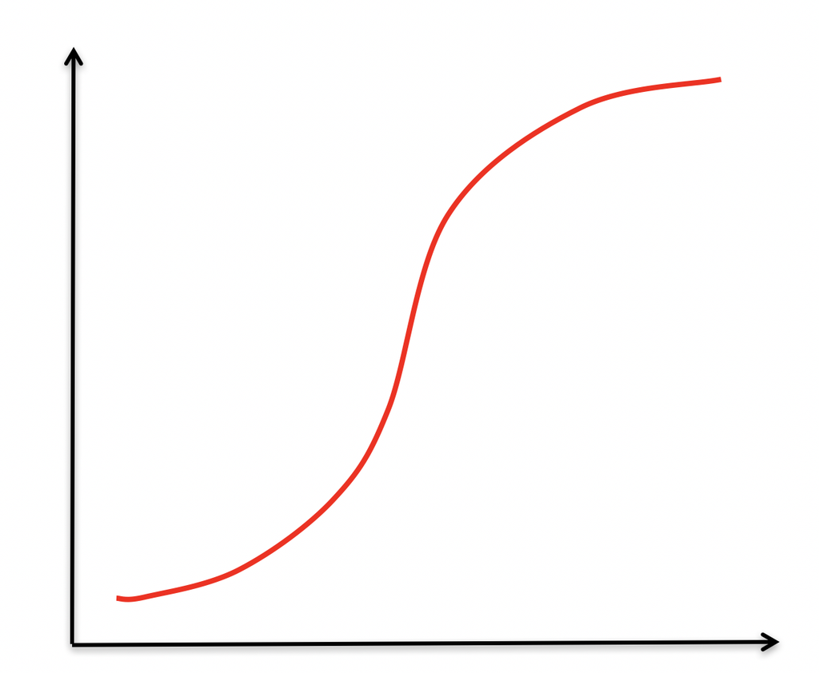

\[ f(x) = \frac{1}{1+e^{-X}} \] \[ \hat{p} = \frac{1}{1+e^{-b_{0}+b_{1}X}} \] - The form of the logistic function is still nonlinear (because probabilities can only range from 0 to 1)  
- Solution is to convert probabilities into odds

## odds

- Odds are defined as the probability of being a case divided by the probability of being a noncase
- Not bound between 0 and 1
- Range from 0 to infinity
- less than one is less than 50% probability \[odds = \frac {\hat{p}}{1-\hat{p}}\]

\[ probability= \frac{\hat{odds}}{1+\hat{odds}} \]

## linear probability model

\[ f(x) = \frac{1}{1+e^{-X}} \] \[ \hat{p} = \frac{1}{1+e^{-b_{0}+b_{1}X}} \]

\[odds = \frac {\hat{p}}{1-\hat{p}}=e^{b_{0}+b_{1}X} \] \[ logit= Log(odds)=ln(\frac{\hat{p}}{1-\hat{p}}) = b_{0}+b_{1}X \]

\[ logit= Log(odds)=ln(\frac{\hat{p}}{1-\hat{p}}) = b_{0}+b_{1}X \]

-Predicted scores are not dichotomous  
-Instead of predicting probabilities directly, we are instead predicting the log of the odds.

## other common link functions

- logit, probit, log-log, poisson, square root…
- exponetial family of probability functions
- note, just because you have a dichotomous outcome you don’t have to run a logistic regression e.g., you can run a probit regression

## estimation

- Maximum likelihood
- OLS minimizes the errors, which also maximize R
- In logistic regression we are not so lucky
- Need to rely on Iterative procedure, ML Estimation
- Asymptotic standard errors (approximations)
- Interpret test statistics as z’s, not t’s
- Wald test = chi square with 1 df = z^2 when F(1, infinity)

## GLM in R

```r
glm(formula, family = gaussian, data, weights, subset,
    na.action, start = NULL, etastart, mustart, offset,
    control = glm.control(...), model = TRUE,
  method = ”glm.fit”, x = FALSE, y = TRUE, contrasts = NULL, ...)
```

## Family Argument

The family argument takes (the name of) a family function which specifies:  
1. the link function  
2. the variance function

```r
glm(y ~ X1+ X2 + X3 , family = binomial, data = dataset)

  binomial(link = "logit")
  gaussian(link = "identity")
  Gamma(link = "inverse")
  inverse.gaussian(link = "1/mu2")   poisson(link = "log")
```

## how to interpret

- b1 is the predicted change in the logit for a 1-unit change in X, holding the other predictors constant
- For a one-unit change in X, holding other predictors constant, the odds that Y = 1 changes by \(e^{b_{1}}\)
- e.g,. \(b_{1}\) = .4, \(e^{.4}\) = 1.49
- for fitted values, need to use entire equation \[ \hat{Y} = e^{b_{0}+b_{1}X_{1}}\]
- turn to probabilities by: odds/(1+odds)

## example

```r
# 0 = premature
mortality
```

```
## # A tibble: 300 x 3
##    Intelligence_Self Intelligence_Mate premature.d
##                <int>             <int>       <dbl>
##  1                22                19          1.
##  2                22                18          1.
##  3                21                21          1.
##  4                22                17          1.
##  5                19                18          1.
##  6                19                20          0.
##  7                16                18          1.
##  8                15                11          0.
##  9                16                21          1.
## 10                19                22          1.
## # ... with 290 more rows
```

```r
death.1 <- lm(premature.d ~ Intelligence_Self , data = mortality)
summary(death.1)
```

```
##
## Call:
## lm(formula = premature.d ~ Intelligence_Self, data = mortality)
##
## Residuals:
##     Min      1Q  Median      3Q     Max
## -0.9030  0.1084  0.1538  0.1907  0.3355
##
## Coefficients:
##                   Estimate Std. Error t value Pr(>|t|)
## (Intercept)       0.641769   0.098636   6.506 3.25e-10 ***
## Intelligence_Self 0.011357   0.005807   1.956   0.0514 .
## ---
## Signif. codes:  0 '***' 0.001 '**' 0.01 '*' 0.05 '.' 0.1 ' ' 1
##
## Residual standard error: 0.3745 on 298 degrees of freedom
## Multiple R-squared:  0.01267,    Adjusted R-squared:  0.009362
## F-statistic: 3.826 on 1 and 298 DF,  p-value: 0.05141
```

```r
death.2 <- glm(premature.d ~ Intelligence_Self , data = mortality)
summary(death.2)
```

```
##
## Call:
## glm(formula = premature.d ~ Intelligence_Self, data = mortality)
##
## Deviance Residuals:
##     Min       1Q   Median       3Q      Max
## -0.9030   0.1084   0.1538   0.1907   0.3355
##
## Coefficients:
##                   Estimate Std. Error t value Pr(>|t|)
## (Intercept)       0.641769   0.098636   6.506 3.25e-10 ***
## Intelligence_Self 0.011357   0.005807   1.956   0.0514 .
## ---
## Signif. codes:  0 '***' 0.001 '**' 0.01 '*' 0.05 '.' 0.1 ' ' 1
##
## (Dispersion parameter for gaussian family taken to be 0.1402466)
##
##     Null deviance: 42.330  on 299  degrees of freedom
## Residual deviance: 41.793  on 298  degrees of freedom
## AIC: 266.05
##
## Number of Fisher Scoring iterations: 2
```

```r
anova(death.1)
```

```
## Analysis of Variance Table
##
## Response: premature.d
##                    Df Sum Sq Mean Sq F value  Pr(>F)
## Intelligence_Self   1  0.537 0.53653  3.8256 0.05141 .
## Residuals         298 41.793 0.14025
## ---
## Signif. codes:  0 '***' 0.001 '**' 0.01 '*' 0.05 '.' 0.1 ' ' 1
```

```r
anova(death.2)
```

```
## Analysis of Deviance Table
##
## Model: gaussian, link: identity
##
## Response: premature.d
##
## Terms added sequentially (first to last)
##
##
##                   Df Deviance Resid. Df Resid. Dev
## NULL                                299     42.330
## Intelligence_Self  1  0.53653       298     41.793
```

```r
death.3 <- glm(premature.d ~ Intelligence_Self,
               family = binomial, data = mortality)
summary(death.3)
```

```
##
## Call:
## glm(formula = premature.d ~ Intelligence_Self, family = binomial,
##     data = mortality)
##
## Deviance Residuals:
##     Min       1Q   Median       3Q      Max
## -2.1175   0.4923   0.5716   0.6438   0.9943
##
## Coefficients:
##                   Estimate Std. Error z value Pr(>|z|)
## (Intercept)        0.28695    0.67490   0.425   0.6707
## Intelligence_Self  0.08012    0.04143   1.934   0.0532 .
## ---
## Signif. codes:  0 '***' 0.001 '**' 0.01 '*' 0.05 '.' 0.1 ' ' 1
##
## (Dispersion parameter for binomial family taken to be 1)
##
##     Null deviance: 273.53  on 299  degrees of freedom
## Residual deviance: 269.75  on 298  degrees of freedom
## AIC: 273.75
##
## Number of Fisher Scoring iterations: 4
```

```r
exp(1)^.08012
```

```
## [1] 1.083417
```

```r
#For every 1 unit increase in Intelligence
#the odds of living increase by 8%.

#prob =
1.083417/(1+1.083417)
```

```
## [1] 0.5200193
```

```r
exp(1)^(.08012*20 + 0.28695)
```

```
## [1] 6.615067
```

```r
6.615067/ (1+6.615067)
```

```
## [1] 0.8686814
```

```r
death.4 <- glm(premature.d ~ Intelligence_Self,
        family = binomial(link = "probit"), data = mortality)
summary(death.4)
```

```
##
## Call:
## glm(formula = premature.d ~ Intelligence_Self, family = binomial(link = "probit"),
##     data = mortality)
##
## Deviance Residuals:
##     Min       1Q   Median       3Q      Max
## -2.1265   0.4889   0.5723   0.6454   0.9750
##
## Coefficients:
##                   Estimate Std. Error z value Pr(>|z|)
## (Intercept)        0.21961    0.38376   0.572   0.5671
## Intelligence_Self  0.04513    0.02319   1.946   0.0516 .
## ---
## Signif. codes:  0 '***' 0.001 '**' 0.01 '*' 0.05 '.' 0.1 ' ' 1
##
## (Dispersion parameter for binomial family taken to be 1)
##
##     Null deviance: 273.53  on 299  degrees of freedom
## Residual deviance: 269.72  on 298  degrees of freedom
## AIC: 273.72
##
## Number of Fisher Scoring iterations: 4
```

## count data

```r
num.rejects <- glm(rejections ~ Intelligence_SelF,
                   family=poisson, data = mortality)
summary(num.rejects)
```